# Optical Properties of Tissue

W. Bauer

01/13/2015

**Reference** Steven L Jacques, Optical properties of biological tissues: a review, 2013, [Phys. Med. Biol. 58 R37](http://iopscience.iop.org/0031-9155/58/11/R37)

The inverse problem subcommittee’s first goal is “a computationally feasible forward model enabling accurate description of light propagation in the human brain.” (Wong, Rahmim, Gjedde, R24 Grant Proposal.) Optical properties of the human brain and enclosing tissues will be required for that purpose. The reference is a recent summary of certain known optical properties of tissue. In the reference, the data is presented as a combination of tables and plots. I’ve converted relevant portions of the data to machine-readable csv format using cut-and-paste for tables and [a plot digitizer](http://plotdigitizer.sourceforge.net/) for graphs. The csv files are available here, here and here.

The three optical properties covered are the reduced scattering coefficient, $\mu_s'$, the anisotropy coefficient, $g$, and the aborption coefficient, $\mu_a$. These quantities are wavelength and tissue dependent, and not all wavelengths and tissues of interest are covered. Moreover, there is a great deal of variability in measurements for a given tissue.

### Scattering

For a forward simulation, a scattering coefficient, $\mu_s$, rather than a *reduced* scattering coefficient is required. The scattering coefficient represents the expected number of scattering events per unit length. Its relationship to the reduced scattering coefficient is given by$g = 1-\frac{\mu_s'}{\mu_s}.$ Both $g$ and $\mu_s$ are very sparesly representated in the data. Moreover, some models of light propagation in tissue, e.g., that of [openGATE](http://www.opengatecollaboration.org/sites/opengatecollaboration.org/files/Cuplov2014.pdf) (PDF), require both forward and backward anisotropy coefficients. These are not represented at all.

For wavelengths of interest, reduced scattering spectra have the following (Rayleigh) form,$\mu_s' = a\left(\frac{\lambda}{500nm}\right)^{-b}.$Measurements are fit to curves and coefficients, $a$, and $b$ tabulated. The following plots give an idea of the variability in measurements. Broken lines indicate two sample standard deviations as computed from data.

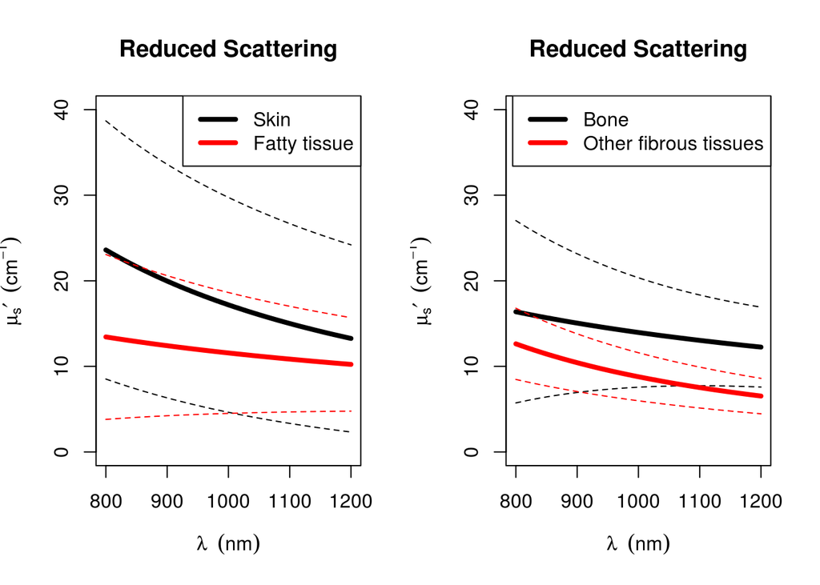

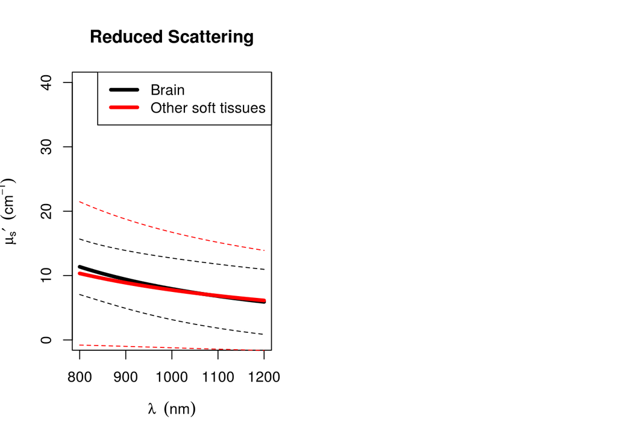

Measurements of the anisotropy coefficients for various tissue and wavelengths are shown below.

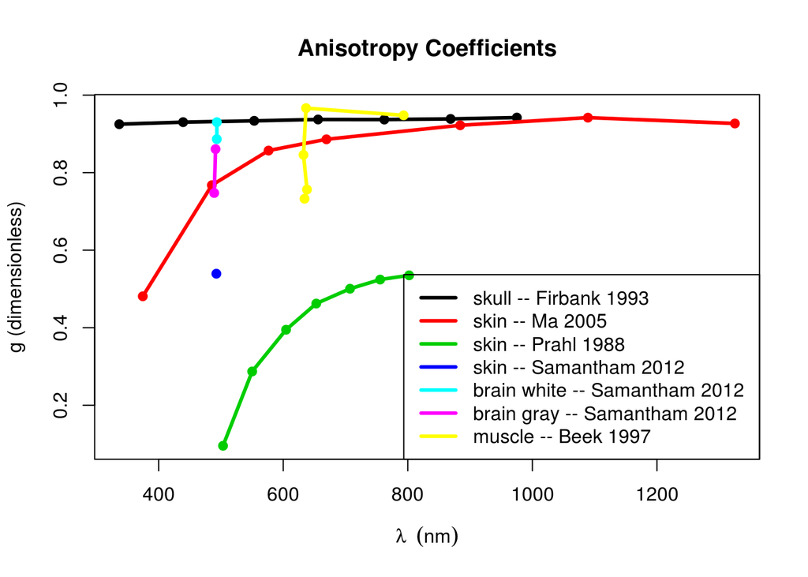

### Absorption

The inverse, $\frac{1}{\mu_a}$ of the absorption coefficient is the expected length of flight before absorption. The absorption properties of a tissue are given parametrically in terms of concentrations and fractional volumes of various chromophores.

| Symbol | Description |
| --- | --- |
| S | HGb oxygen saturation of mixed arterio-venous vasculature |
| B | average blood volume fraction |
| W | water content (fractional volume) |
| Bili | bilirubin concentration |
| βC | β-carotene concentration |
| F | fat content (fractional volume) |
| M | melanosome volume fraction |

Given values for these 7 parameters, the absorption coefficient of a corresponding tissue is a linear combination of chromophore coefficients,$\mu_a(\lambda) = BS\mu_{a.oxy}(\lambda) + B(1-S)\mu_{a.deoxy}(\lambda) + W\mu_{a.water}(\lambda) + F\mu_{a.fat}(\lambda) + M\mu_{a.melanosome}(\lambda) + 2.3Bili \cdot \varepsilon_{bili}(\lambda) + 2.3\beta C \varepsilon_{\beta C}(\lambda),$where the $\mu_a$’s are absorption coefficients of the indicated chromophores, and the $\varepsilon$’s are extinction coefficients of bilirubin and β-carotene.

Melanosome absorption fits the following power law in which $m$ is approximately 3.$\mu_{a.melanosome} = (519 \: cm^{-1})\left(\frac{\lambda}{500 \: nm}\right)^{-m}.$The remaining chromophore spectra are given empirically.

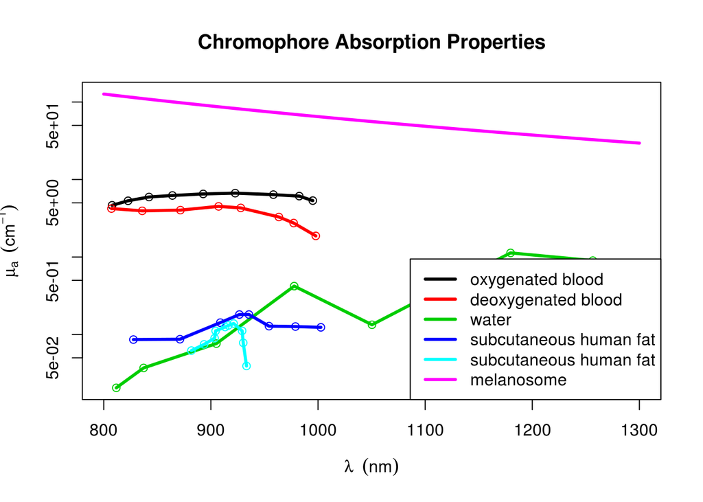

### Refraction

According to the reference, the value of the real refraction coefficient, n, of tissue scales linearly with its water content, W,$n = n_{dry} − (n_{dry} − n_{water})W,$ where $n_{dry} \approx 1.514$ and $n_{water} = 1.33.$ The following values are from [T Biswas, T Luu. In vivo MR Measurement of Refractive Index, Relative Water Content and T2 Relaxation time of Various Brain lesions With Clinical Application to Discriminate Brain Lesions. The Internet Journal of Radiology. 2009 Volume 13 Number 1.](https://ispub.com/IJRA/13/1/8277#)

| Tissue | W |
| --- | --- |
| CSF | 1.0 |
| Gray matter | 0.8 |
| White matter | 0.7 |

download Rmd file (includes source code)

download csv data files: Reduced Scattering, Anisotropy, Absorption